# team.Rmd

Dana Thacker, Andrew Fahmy

3/15/2021

```r
library(readxl)
library(tidyverse)
```

```r
library(ggplot2)
defense <- read_excel('cyclonesFootball2020.xlsx', sheet='Defensive')
offense <- read_excel('cyclonesFootball2020.xlsx', sheet='Offensive')
biography <- read_excel('cyclonesFootball2020.xlsx', sheet='Biography')
```

**Part One: Cleaning Data** Although the three Excel sheets are loaded into R, they are not useful before some cleaning. Manipulate the three imported data frames, so that in the cleaned dataset: *Problem 1* The player names and opponent names are factors.

```r
defense <- defense %>%
  mutate(Name = as.factor(Name),
         Opponent_Opponent = as.factor(Opponent_Opponent))

offense <- offense %>%
  mutate(Name = as.factor(Name),
         Opponent_Opponent = as.factor(Opponent_Opponent))

biography <- biography %>%
  mutate(Name = as.factor(Name))
```

*Problem 2* All offensive and defensive statistics are numerical. The Weight column in biography is also numeric. (Optional: Read ?across and learn to mutate multiple columns simultaneously using the across function in dplyr)

```r
defense <- defense %>%
  mutate(across(Tackles_Solo:Pass_PB, as.numeric))

offense <- offense %>%
  mutate(across(Receiving_REC:Passing_INT, as.numeric))
```

```r
biography <- biography %>%
  mutate(Weight = as.numeric(Weight))
```

*Problem 3* Change the Height column in biography into numeric. (Hint: Use a unit that works well)

```r
biography <- biography %>%
  separate(Height, c('Feet', 'Inches'), sep='-')

biography <- biography %>%
  mutate(Feet = as.numeric(Feet),
         Inches = as.numeric(Inches))
```

**Part 2: Tidying Data** *Problem 1* Reformat the offClean data frame into a tidy format using pivot_longer. The type of statistic (Receiving_REC for the number of receptions, Receiving_YDS for receiving yards, etc) is added as a new key column named stat.

```r
offClean <- offense %>%
  pivot_longer(Receiving_REC:Passing_INT, names_to = 'Type', values_to = 'Stat')
```

*Problem 2* Show on the distributions of the offensive statistics. The distribution of each offensive statistics should be shown in a separate facet. Explain the patterns you see.

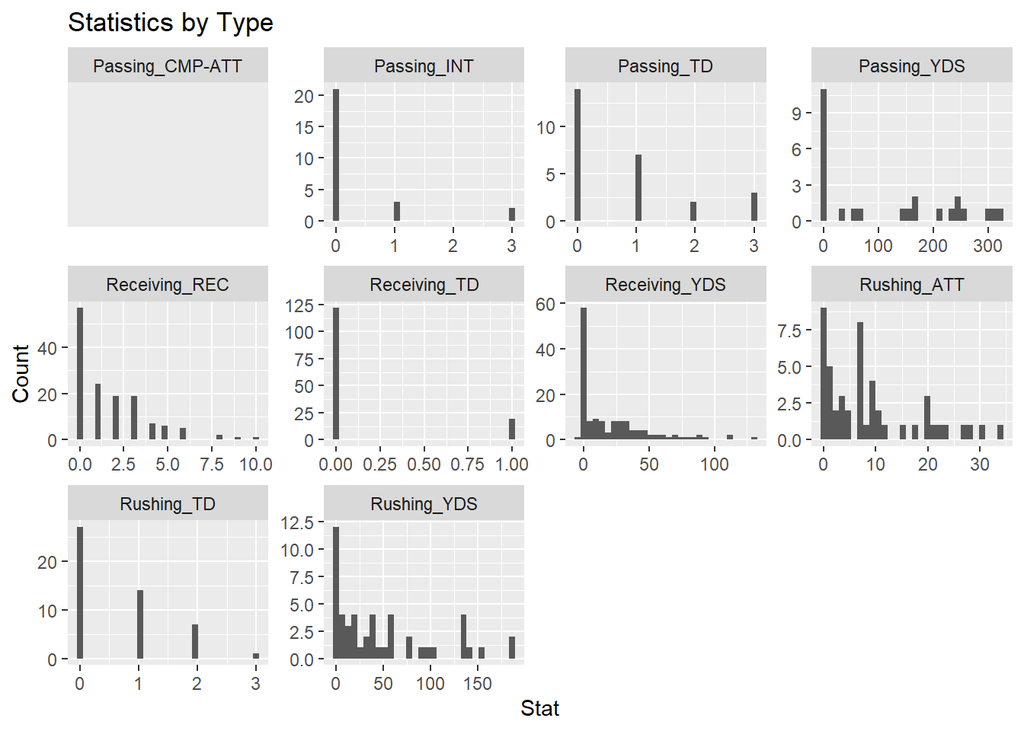

```r
ggplot(offClean, aes(x = Stat)) + geom_histogram() + facet_wrap(~ Type, scales = 'free') + xlab("Stat") + ylab("Count") + ggtitle("Statistics by Type")
```

*Problem 3* Did ISU have better offense against Oregon or Oklahoma? Answer this question by creating a scatterplot with the x- and y-axes being the receiving yards of the ISU players against these two opponents. A large number of receiving yards indicates good offense.

```r
offOreOkl <- offClean %>%
  filter(Opponent_Opponent %in% c("Oregon", "Oklahoma")) %>%
  group_by(Name) %>%
  filter(Type == "Receiving_YDS")

offOklahoma <- offOreOkl %>%
  filter(Opponent_Opponent %in% c("Oklahoma")) %>%
  group_by(Name) %>%
  summarise(Average = mean(Stat))

offOregon <- offOreOkl %>%
  filter(Opponent_Opponent %in% c("Oregon"))

offOreOklAvg <- offOreOkl %>%
  left_join(offOklahoma)
offOreOklPivoted <- offOreOklAvg %>%
  pivot_wider(names_from = 'Type', values_from = 'Stat') %>%
  filter(Opponent_Opponent %in% c("Oregon")) %>%
  rename(Oklahoma_Receiving_YDS = Average,
         Oregon_Receiving_YDS = Receiving_YDS) %>%
  mutate(Oklahoma_Receiving_YDS = as.numeric(Oklahoma_Receiving_YDS),
         Oregon_Receiving_YDS = as.numeric(Oregon_Receiving_YDS))
```

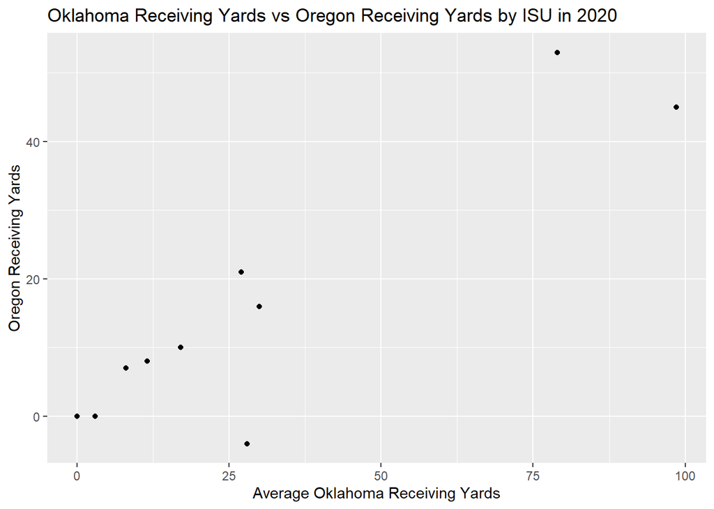

```r
ggplot(offOreOklPivoted, aes(x = Oklahoma_Receiving_YDS, y = Oregon_Receiving_YDS)) + geom_point() + xlab("Average Oklahoma Receiving Yards") + ylab("Oregon Receiving Yards") + ggtitle("Oklahoma Receiving Yards vs Oregon Receiving Yards by ISU in 2020")
```

*Problem 4* Separate the Hometown column into two columns, namely, the city and the state where the player comes from. Print the first few rows of these two columns. (Hint: look at the sep= argument of separate)

```r
biography <- biography %>%
  separate(Hometown, c('City', 'State'), sep = ', ')

head(biography, 4)
```

```
## # A tibble: 4 x 9
##   Name       Position    Feet Inches Weight Class     City     State Highschool
##   <fct>      <chr>      <dbl>  <dbl>  <dbl> <chr>     <chr>    <chr> <chr>
## 1 Akers, La~ Wide Rece~     6      0    191 Redshirt~ Cedar R~ Iowa  Washington
## 2 Allen, Ch~ Tight End      6      7    240 Redshirt~ Nixa     Mo.   Nixa
## 3 Anderson,~ Wide Rece~     6      5    208 Redshirt~ Seffner  Fla.  Armwood
## 4 Antoine J~ Defensive~     6      0    180 Freshman  Ft. Lau~ Fla.  Cardinal G~
```

*Problem 5* How many players are there from each state?

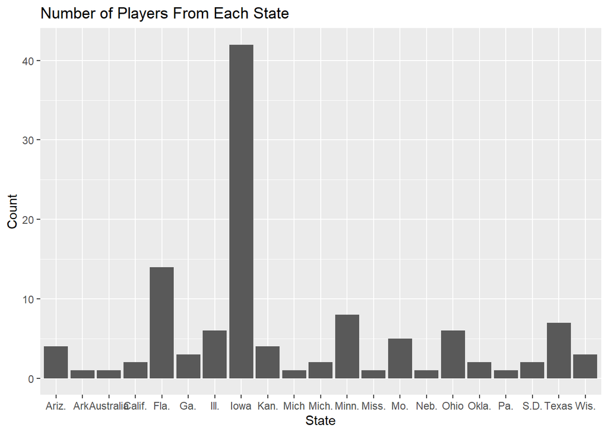

```r
ggplot(biography, aes(x = State)) + geom_bar() + xlab("State") + ylab("Count") + ggtitle("Number of Players From Each State")
```

**Part 3: Joining Data Frames** *Problem 1* Find which states do the ISU players (both defensive and offensive) come from. Create an appropriate numerical or graphical summary.

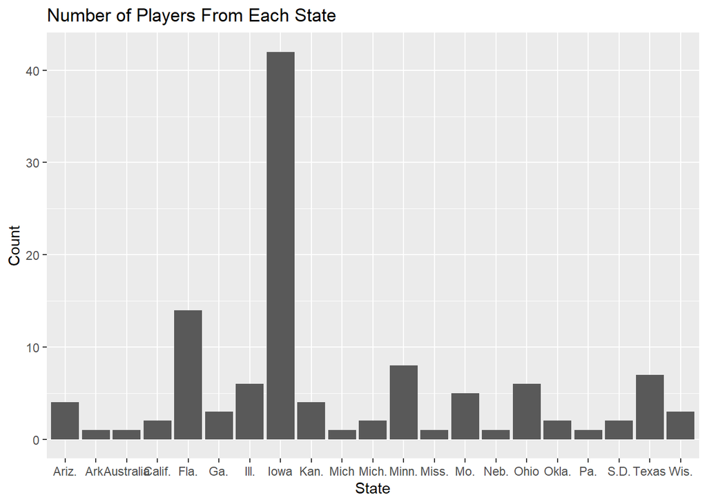

```r
ggplot(biography, aes(x = State)) + geom_bar() + xlab("State") + ylab("Count") + ggtitle("Number of Players From Each State")
```

*Problem 2* How does the performance of quarterback Brock Purdy relate to the performance of the ISU team?

```r
brock = colSums(offense %>% filter(Name == "Purdy, Brock") %>% select(-c("Name", "Opponent_Opponent")), na.rm = TRUE)
team = colSums(offense %>% filter(Name != "Purdy, Brock") %>% select(-c("Name", "Opponent_Opponent")), na.rm = TRUE)

dat = data.frame(brock, team)
dat = data.frame(t(dat))
dat
```

```
##       Receiving_REC Receiving_YDS Receiving_TD Rushing_ATT Rushing_YDS
## brock             0             0            0          87         382
## team            242          2845           19         356        1969
##       Rushing_TD Passing_CMP.ATT Passing_YDS Passing_TD Passing_INT
## brock          5               0        2750         19           9
## team          26               0         146          1           0
```

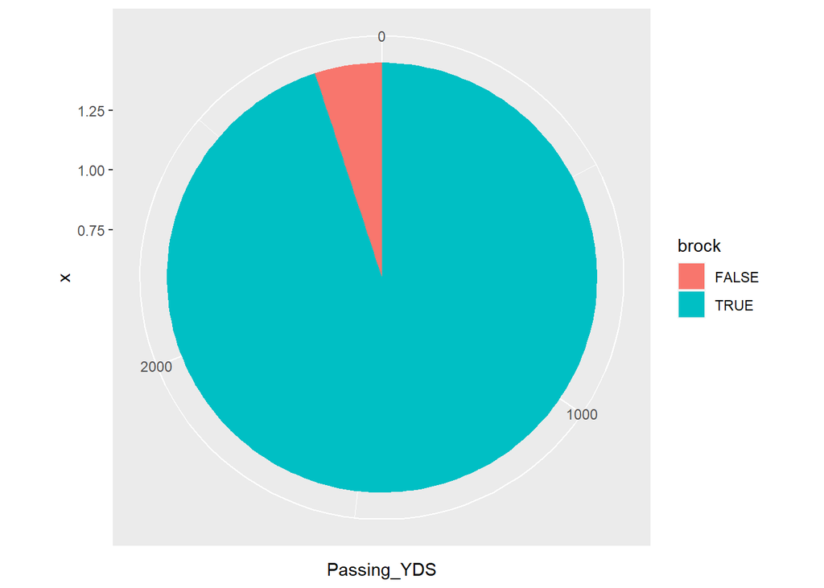

```r
datt = offense
datt$brock = datt$Name=="Purdy, Brock"

datt  %>% ggplot(aes(x=1,y=Passing_YDS, fill=brock)) + geom_col() + coord_polar(theta = 'y')
```

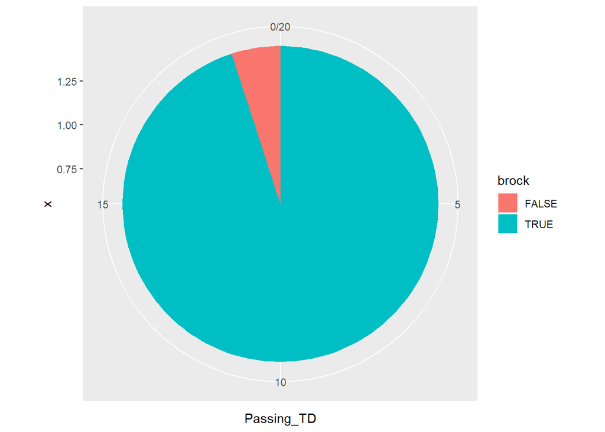

```r
datt  %>% ggplot(aes(x=1,y=Passing_TD, fill=brock)) + geom_col() + coord_polar(theta = 'y')
```

As we can see from the data and the graph, almost all of the offensive yards thrown as well as touch downs are from Brock. This shows that the teams performance is extremely relient on the performance of brock.

*Problem 3* Which ISU player(s) made the biggest progress over the last year? Compare the player-level statistics (i.e. averages and totals for each player) using both the 2020 and the 2019 data here. Choose for yourself the player statistics to investigate.

```r
defense1 <- read_excel('cyclonesFootball2019.xlsx', sheet='Defensive')
offense1 <- read_excel('cyclonesFootball2019.xlsx', sheet='Offensive')
biography1 <- read_excel('cyclonesFootball2019.xlsx', sheet='Biography')

defense1 <- defense1 %>%
  mutate(across(Tackles_Solo:Pass_PB, as.numeric))

offense1 <- offense1 %>%
  mutate(across(Rushing_ATT:Passing_INT, as.numeric))
defense1 <- defense1 %>%
  mutate(Name = as.factor(Name),
         Opponent_Opponent = as.factor(Opponent_Opponent))

offense1 <- offense1 %>%
  mutate(Name = as.factor(Name),
         Opponent_Opponent = as.factor(Opponent_Opponent))

offense2 = offense %>% filter(Name %in% offense1$Name)
offense3 = offense1 %>% filter(Name %in% offense$Name)

mean1 = aggregate(x=offense2$Receiving_YDS, by=list(offense2$Name), FUN=mean)
mean1$ave_2020 = aggregate(x=offense3$Receiving_YDS, by=list(offense3$Name), FUN=mean)$x

mean1$improvement = mean1$ave_2020 - mean1$x

mean1[order(mean1$improvement), ]
```

```
##            Group.1         x   ave_2020 improvement
## 1    Akers, Landen 22.416667  8.3846154 -14.0320513
## 11  Soehner, Dylan 18.636364  8.9166667  -9.7196970
## 9      Scates, Joe 12.181818  2.5000000  -9.6818182
## 2     Allen, Chase 21.454545 12.8461538  -8.6083916
## 7    Nwangwu, Kene  1.833333  0.6153846  -1.2179487
## 5   Kolar, Charlie 53.727273 53.6153846  -0.1118881
## 10  Shaw Jr., Sean 17.666667 21.0000000   3.3333333
## 4     Hall, Breece 15.000000 21.0000000   6.0000000
## 6  Milton, Tarique 17.000000 55.5384615  38.5384615
## 3    Brock, Jirehl  3.200000         NA          NA
## 8     Purdy, Brock        NA         NA          NA
```

```r
defense2 = defense %>% filter(Name %in% defense1$Name)
defense3 = defense1 %>% filter(Name %in% defense$Name)

mean2 = aggregate(x=defense2$Tackles_Solo, by=list(defense2$Name), FUN=mean)
mean2$ave_2020 = aggregate(x=defense3$Tackles_Solo, by=list(defense3$Name), FUN=mean)$x

mean2$improvement = mean2$ave_2020 - mean2$x

mean2[order(mean2$improvement), ]
```

```
##              Group.1          x   ave_2020 improvement
## 8         Rose, Mike 4.50000000 3.00000000 -1.50000000
## 4       Hummel, Jake 3.33333333 1.92307692 -1.41025641
## 3     Bailey, JaQuan 1.66666667 0.50000000 -1.16666667
## 13     Vaughn, Gerry 0.83333333 0.07692308 -0.75641026
## 15    Young, Datrone 1.63636364 0.92307692 -0.71328671
## 14     Walling, Rory 0.50000000 0.23076923 -0.26923077
## 5     King, Kym-Mani 0.50000000 0.30769231 -0.19230769
## 9         Rus, Jared 0.18181818 0.00000000 -0.18181818
## 2     Azunna, Arnold 1.66666667 1.63636364 -0.03030303
## 11 Uwazurike, Eyioma 1.33333333 1.46153846  0.12820513
## 10    Soehner, Dylan 0.09090909 0.25000000  0.15909091
## 12     Vance, O'Rien 2.50000000 2.83333333  0.33333333
## 1      Akers, Landen 0.25000000 0.69230769  0.44230769
## 7     Petersen, Zach 0.58333333 1.76923077  1.18589744
## 6      Kyle, Tayvonn 1.66666667 3.14285714  1.47619048
```

We can see that for offense, Akers, Landen had an average of 14 more receiving yards from the previous year.

As for defense we can see that Rose, Mike had an average of 1.5 more solo tackles in 2020.